# Trajectory inference with Slingshot

Local version, reads from the workshop data repo, no network access

Published

August 4, 2026

Local rework of `1_a_slingshot.html`.

Upstream: https://nbisweden.github.io/workshop-archive/workshop-scRNAseq/2020-01-27/labs/compiled/slingshot/slingshot.html (NBIS workshop-scRNAseq, 2020-01-27 archive)

Method: Street et al. 2018, “Slingshot: cell lineage and pseudotime inference for single-cell transcriptomics”, BMC Genomics, https://doi.org/10.1186/s12864-018-4772-9

**NoteStatus: transcribed from upstream, renders cleanly end to end**

The code below is transcribed from the upstream lab, with the GEO download replaced by a read from the staged data repo. Three changes were needed to run under current package versions: `buildSNNGraph()` no longer takes `assay.type` when a reduction is supplied, and `getLineages()` / `getCurves()` now return a `PseudotimeOrdering`, so they are wrapped in `SlingshotDataSet()` before the base-graphics `lines()` calls.

## Setup

```r
data_dir <- "~/MEGA/workshop_data/1_a_slingshot"
in_data_dir <- function(basename) {
  return(file.path(data_dir, basename))
}
```

```r
suppressPackageStartupMessages({
  library(Matrix)
  library(scran)
  library(scater)
  library(igraph)
  library(slingshot)
  library(tradeSeq)
  library(dplyr)
  library(cowplot)
  library(RColorBrewer)
})
```

## Load data

Mouse bone marrow progenitors, GEO GSE72857 (Paul et al. 2015).

Upstream downloads `GSE72857_umitab.txt.gz` from the NCBI FTP server, decompresses it, reads it with `read.delim()`, and converts it to a sparse matrix. The staging script does all of that once and saves the sparse matrix, so here we just read it.

**NoteStaged file**

`GSE72857_umitab.rds`, a sparse `dgCMatrix` of raw UMI counts, genes by cells. Produced by `staging/stage_1_a_slingshot.R`.

```r
umi_counts <- readRDS(file.path(data_dir, "GSE72857_umitab.rds"))

# Select every fifth cell, to keep the exercise fast.
umi_counts <- umi_counts[, c(TRUE, FALSE, FALSE, FALSE, FALSE)]
dim(umi_counts)
```

```
[1] 27297  2074
```

```r
# Colour palette used throughout.
pal <- c(RColorBrewer::brewer.pal(9, "Set1"), RColorBrewer::brewer.pal(8, "Set2"))
```

## Basic processing with the Scran / Scater pipeline

Upstream offers a Scran/Scater route and a Seurat route, and they are alternatives, not steps. We use Scran/Scater because it keeps the object a `SingleCellExperiment`, which is what Slingshot wants anyway. The Seurat route is kept below but not run.

The goal of this section is only to produce two things, a reduction to run the trajectory on, and a clustering.

```r
data <- SingleCellExperiment(assays = list(counts = umi_counts))
data <- computeSumFactors(data, sizes = c(20, 40, 60, 80))
data <- logNormCounts(data)
var.fit <- modelGeneVar(data)
top.hvgs <- getTopHVGs(var.fit, n = 2000)
data <- runPCA(data, subset_row = top.hvgs)
g <- buildSNNGraph(data, k = 5, use.dimred = "PCA")
data$louvain_SNNk5 <- factor(igraph::cluster_louvain(g)$membership)
data <- runUMAP(data, dimred = "PCA", n_dimred = 50, ncomponents = 2,
                spread = 2, min_dist = 0.1, n_neighbors = 10, metric = "cosine")
```

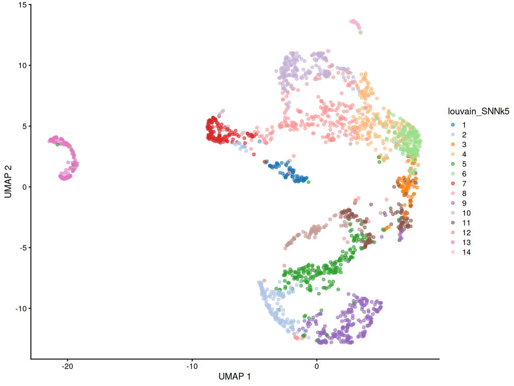

```r
plotReducedDim(data, dimred = "UMAP", colour_by = "louvain_SNNk5")
```

```r
# Slingshot takes plain matrices, not the SingleCellExperiment.
dimred     <- reducedDim(data, type = "UMAP")
clustering <- data$louvain_SNNk5
counts     <- as.matrix(counts(data)[top.hvgs, ])
```

## Alternative: the Seurat route

Not run. Shown because students who did the earlier days in Seurat will want to see how they get to the same two objects.

```r
library(Seurat)
data_seurat <- CreateSeuratObject(counts = umi_counts)
data_seurat <- NormalizeData(data_seurat)
data_seurat <- FindVariableFeatures(data_seurat, nfeatures = 2000)
data_seurat <- ScaleData(data_seurat)
data_seurat <- RunPCA(data_seurat)
data_seurat <- FindNeighbors(data_seurat)
data_seurat <- FindClusters(data_seurat, resolution = 1)
data_seurat <- RunUMAP(data_seurat, n.neighbors = 10, dims = 1:50,
                       spread = 2, min.dist = 0.3)
DimPlot(data_seurat, group.by = "RNA_snn_res.1")

dimred     <- data_seurat@reductions$umap@cell.embeddings
clustering <- data_seurat$RNA_snn_res.1
counts     <- as.matrix(data_seurat@assays$RNA@counts[
  data_seurat@assays$RNA@var.features, ])
```

## Defining cell lineages with Slingshot

`slingshot()` is a wrapper around two steps. First define the lineages, which are paths through the clusters. Then fit a curve through the data for each lineage. They are shown separately here for clarity.

```r
set.seed(1)
lineages <- getLineages(data = dimred, clusterLabels = clustering)
lineages
```

```
class: PseudotimeOrdering
dim: 2074 8
metadata(3): lineages mst slingParams
pathStats(2): pseudotime weights
cellnames(2074): W29953 W29958 ... W76329 W76334
cellData names(2): reducedDim clusterLabels
pathnames(8): Lineage1 Lineage2 ... Lineage7 Lineage8
pathData names(0):
```

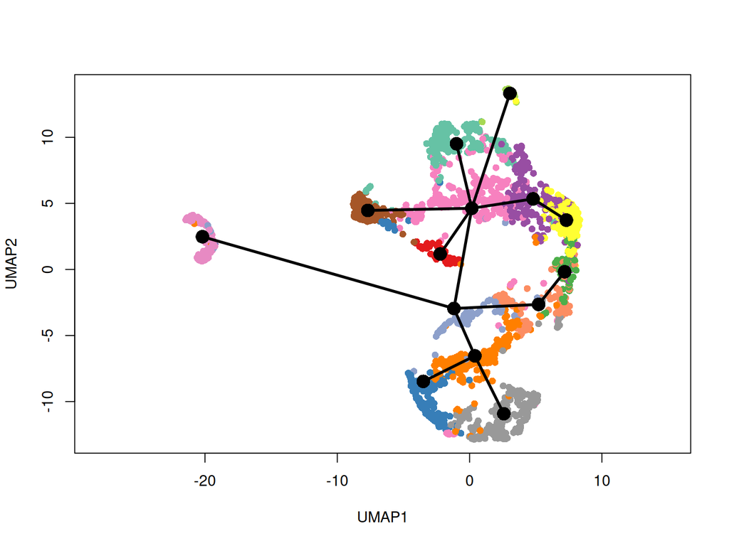

```r
plot(dimred, col = pal[clustering], asp = 1, pch = 16)
# getLineages() now returns a PseudotimeOrdering; the base-graphics lines()
# method is defined for SlingshotDataSet, so convert before plotting.
lines(SlingshotDataSet(lineages), lwd = 3, col = "black")
```

## Defining principal curves

Principal curves iteratively deform an initial curve to fit the data. Slingshot runs one per lineage, and bundles curves that share clusters.

`approx_points = 300` is a speed compromise. With all cells this is slow.

```r
curves <- getCurves(lineages, approx_points = 300, thresh = 0.01,
                    stretch = 0.8, allow.breaks = FALSE, shrink = 0.99)
curves
```

```
class: PseudotimeOrdering
dim: 2074 8
metadata(4): lineages mst slingParams curves
pathStats(2): pseudotime weights
cellnames(2074): W29953 W29958 ... W76329 W76334
cellData names(2): reducedDim clusterLabels
pathnames(8): Lineage1 Lineage2 ... Lineage7 Lineage8
pathData names(0):
```

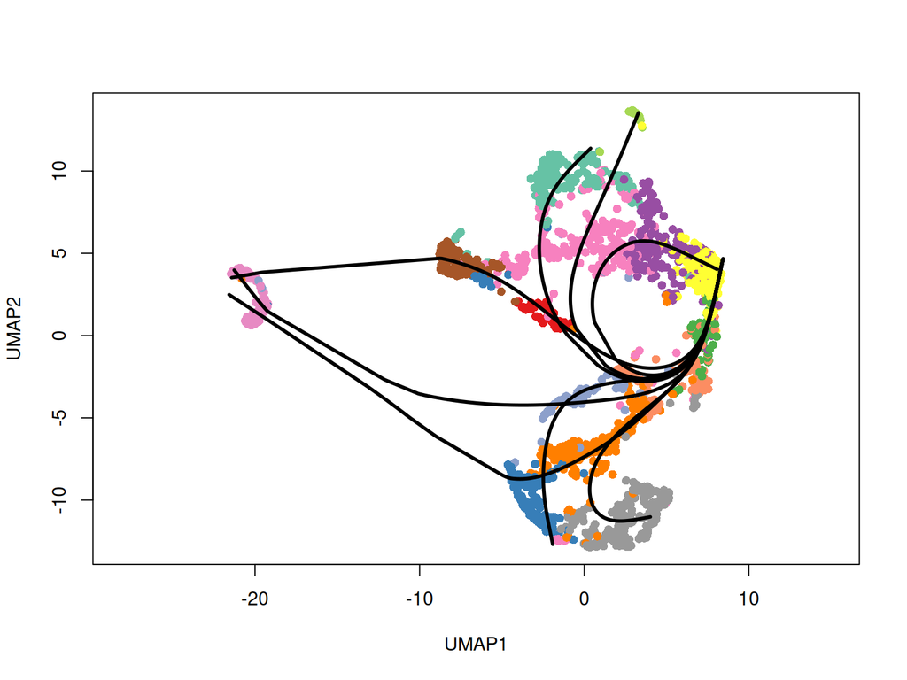

```r
plot(dimred, col = pal[clustering], asp = 1, pch = 16)
lines(SlingshotDataSet(curves), lwd = 3, col = "black")
```

## Finding differentially expressed genes

tradeSeq smooths expression along the trajectory with generalized additive models, then tests whether coefficients differ between points on the trajectory.

```r
BiocParallel::register(BiocParallel::SerialParam())
```

**Warning`fitGAM` is the slow step**

If this is still too slow on the workshop machine, precompute the fitted object in the staging script and read it here instead.

```r
# Stringent filter, for speed only.
filt_counts <- counts[rowSums(counts > 5) > ncol(counts) / 100, ]
dim(filt_counts)
```

```
[1]  287 2074
```

```r
sce <- fitGAM(counts = as.matrix(filt_counts), sds = curves)
```

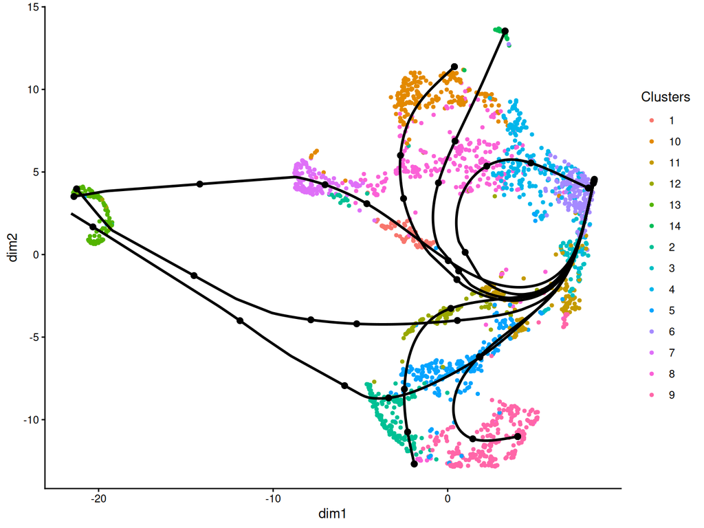

```r
plotGeneCount(curves, filt_counts, clusters = clustering, models = sce)
```

### Genes that change with pseudotime

```r
pseudotime_association <- associationTest(sce)
pseudotime_association$fdr <- p.adjust(pseudotime_association$pvalue,
                                       method = "fdr")
pseudotime_association <- pseudotime_association[
  order(pseudotime_association$pvalue), ]
pseudotime_association$feature_id <- rownames(pseudotime_association)
head(pseudotime_association, 20)
```

```
                     waldStat df       pvalue meanLogFC          fdr
Mthfd1              250.85827 42 0.000000e+00 1.3770819 0.000000e+00
rp9                 174.80658 42 0.000000e+00 0.8633444 0.000000e+00
Gnl3                146.76652 42 1.553202e-13 1.3763231 5.177340e-13
Calm2               140.78576 42 1.365019e-12 1.0151846 3.412548e-12
Bat2d;Prrc2c;Bat2l2 123.57980 42 5.786595e-10 0.6429836 1.157319e-09
Fcer1g              113.58140 42 1.652587e-08 1.0675996 2.754312e-08
1100001G20Rik        94.05926 42 7.355549e-06 3.9881176 1.050793e-05
Fen1                 92.41459 42 1.190346e-05 0.9925970 1.487933e-05
Ldha                 86.90397 42 5.718920e-05 0.7624293 6.354356e-05
Gsto1                56.96679 42 6.149410e-02 0.5751385 6.149410e-02
Prtn3                      NA NA           NA 1.1454104           NA
Mpo                        NA NA           NA 1.2053784           NA
Elane                      NA NA           NA 1.4149206           NA
Car1                       NA NA           NA 2.0981303           NA
Ctsg                       NA NA           NA 1.1976583           NA
Car2                       NA NA           NA 1.5690537           NA
Cd74                       NA NA           NA 4.6322473           NA
Atpase6                    NA NA           NA 0.7207722           NA
H2-Aa                      NA NA           NA 3.9219448           NA
Eef1a1                     NA NA           NA 1.9445006           NA
                             feature_id
Mthfd1                           Mthfd1
rp9                                 rp9
Gnl3                               Gnl3
Calm2                             Calm2
Bat2d;Prrc2c;Bat2l2 Bat2d;Prrc2c;Bat2l2
Fcer1g                           Fcer1g
1100001G20Rik             1100001G20Rik
Fen1                               Fen1
Ldha                               Ldha
Gsto1                             Gsto1
Prtn3                             Prtn3
Mpo                                 Mpo
Elane                             Elane
Car1                               Car1
Ctsg                               Ctsg
Car2                               Car2
Cd74                               Cd74
Atpase6                         Atpase6
H2-Aa                             H2-Aa
Eef1a1                           Eef1a1
```

```r
# Upstream defines a helper that immediately overwrites its own argument, so it
# always plots the same gene no matter what you pass it. Fixed here to actually
# use the argument.
plot_differential_expression <- function(feature_id) {
  cowplot::plot_grid(
    plotGeneCount(curves, filt_counts, gene = feature_id[1],
                  clusters = clustering, models = sce) +
      ggplot2::theme(legend.position = "none"),
    plotSmoothers(sce, as.matrix(counts), gene = feature_id[1]))
}
```

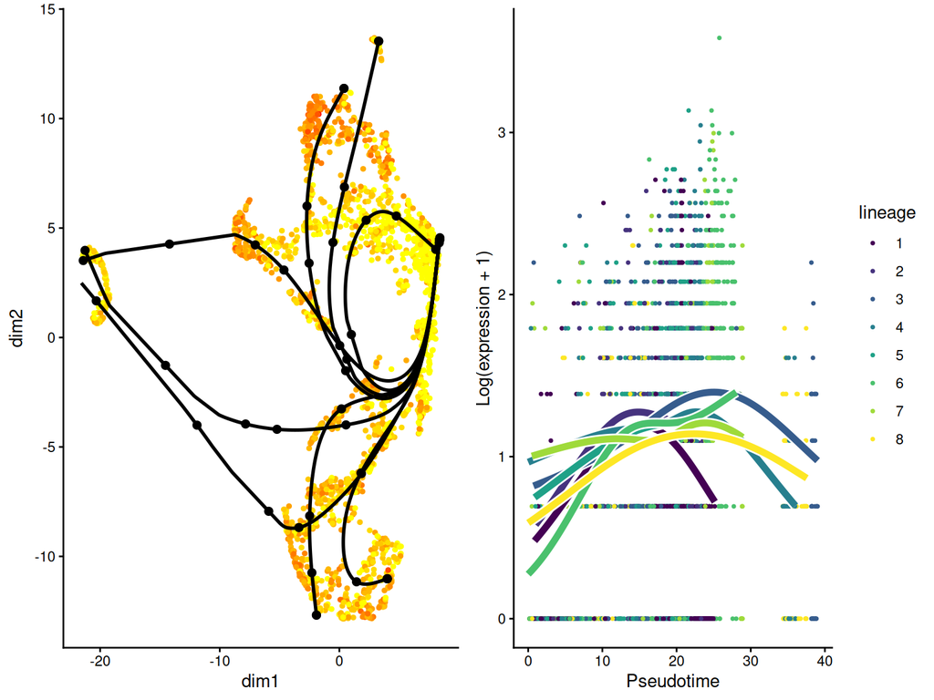

```r
feature_id <- pseudotime_association |>
  dplyr::filter(pvalue < 0.05) |>
  dplyr::top_n(1, -waldStat) |>
  dplyr::pull(feature_id)

plot_differential_expression(feature_id)
```

### Genes that change between two pseudotime points

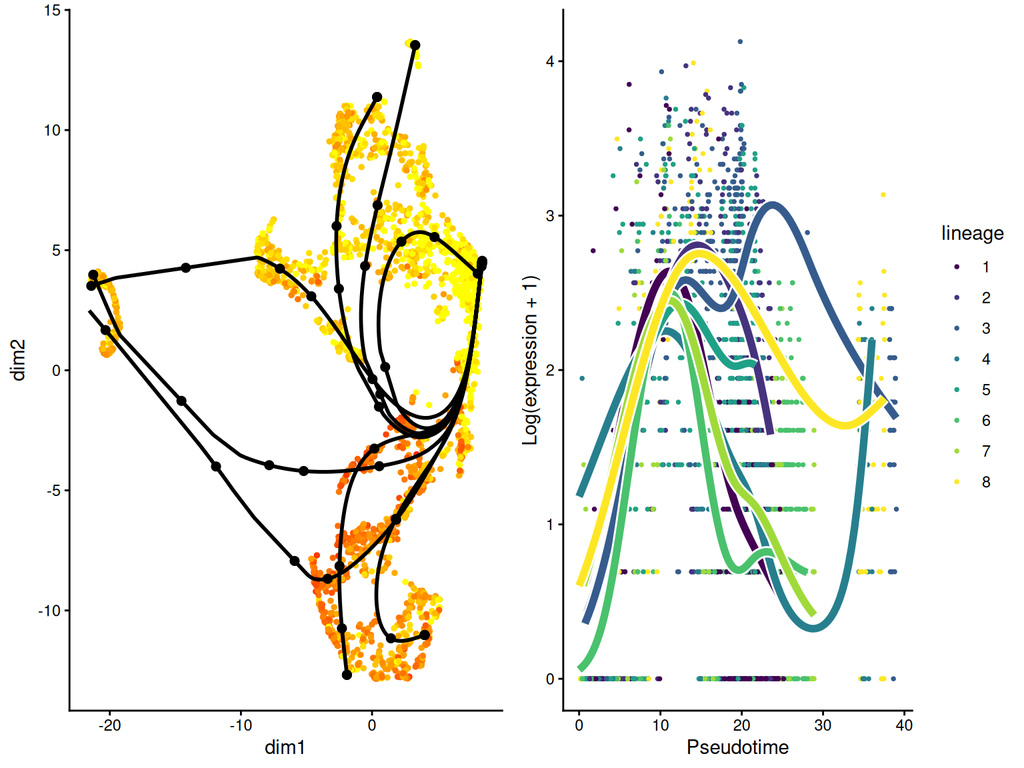

```r
pseudotime_start_end_association <- startVsEndTest(sce, pseudotimeValues = c(0, 1))
pseudotime_start_end_association$feature_id <-
  rownames(pseudotime_start_end_association)

feature_id <- pseudotime_start_end_association |>
  dplyr::filter(pvalue < 0.05) |>
  dplyr::top_n(1, waldStat) |>
  dplyr::pull(feature_id)

plot_differential_expression(feature_id)
```

### Genes that are different between lineages

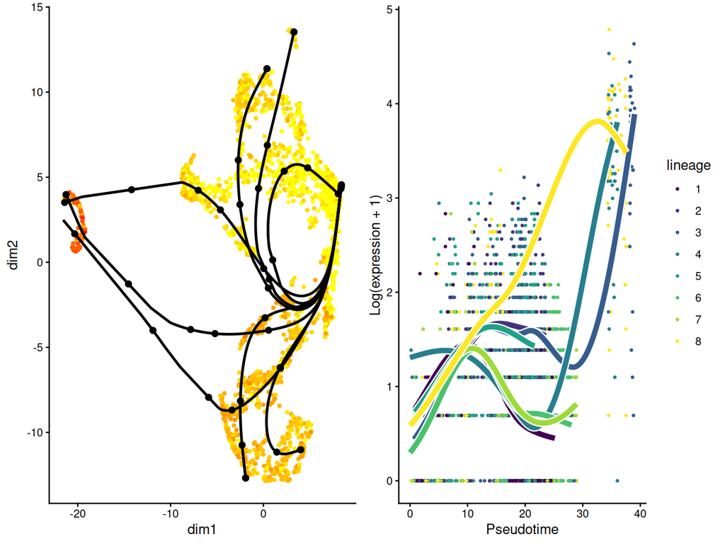

```r
different_end_association <- diffEndTest(sce)
different_end_association$feature_id <- rownames(different_end_association)

feature_id <- different_end_association |>
  dplyr::filter(pvalue < 0.05) |>
  dplyr::arrange(dplyr::desc(waldStat)) |>
  dplyr::slice(1) |>
  dplyr::pull(feature_id)

plot_differential_expression(feature_id)
```